# Лабораторная работа №7

Элементы криптографии. Однократное гаммирование

Сергеев Даниил Олегович

1132246837@rudn.ru

Российский университет дружбы народов

2026-05-16

# Информация

## Докладчик

- Сергеев Даниил Олегович
- Студент
- Направление: Прикладная информатика
- Российский университет дружбы народов
- 1132246837@pfur.ru
- https://github.com/FrigatZero

# Цель работы

Освоить на практике применение режима однократного гаммирования.

# Выполнение лабораторной работы

Войдем в систему и создадим файл программы на языке C в каталоге `~/testing`. Назовем его `gamma.c`.

```bash
cd ~/testing
vi gamma.c
```

Будем принимать ключ, открытый текст и шифротекст через аргументы программы:

- Опция `-k` : ключ в hex формате
- Опция `-o` : открытый текст в hex формате
- Опция `-e` : шифротекст в hex формате
- Формат: `00 01 02 ... 1F 2F ...`

Для удобства будем использовать байт-буфферы фиксированного размера. Сложение по модулю будем применять для всех элементов двух массивов.

## Выполнение лабораторной работы

На выход программа будет выводить введенные данные (открытый текст будет отображен в символьном и в шестнадцатеричном формате). В зависимости от входных аргументов:

- Если есть ключ и открытый текст (`new_text`, `test_decrypt`): будет выводится шифротекст, полученный путем применения сложения по модулю ключа и текста;
- Если есть шифротекст и ключ (`decrypt`): будет выводится расшифровка шифротекста (в байтах и в строчном виде);
- Если есть шифротекст и открытый текст (`desired_key`): будет выводится ключ, необходимый для преобразования шифротекста в приведенный открытый текст.

## Выполнение лабораторной работы

Скомпилируем программу и проведем пробный запуск.

```bash
cd ~/testing
ls
gcc gamma.c -o gamma
./gamma
```

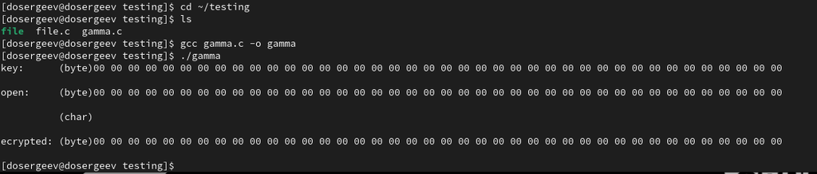

Рисунок 1: Вывод программы без аргументов

## Выполнение лабораторной работы

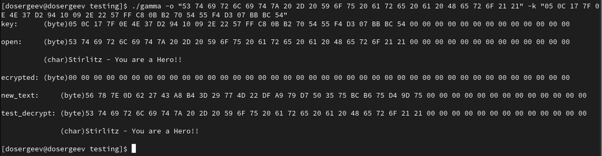

Рисунок 2: Шифрование фразы `Stirlitz - You are a Hero!!`

Проверка ключа показывает, что мы правильно создали шифротекст. Теперь попробуем создать ключ для открытого текста `Happy New Year, Friends!!!!` и зашифрованного текста, полученного ранее.

## Выполнение лабораторной работы

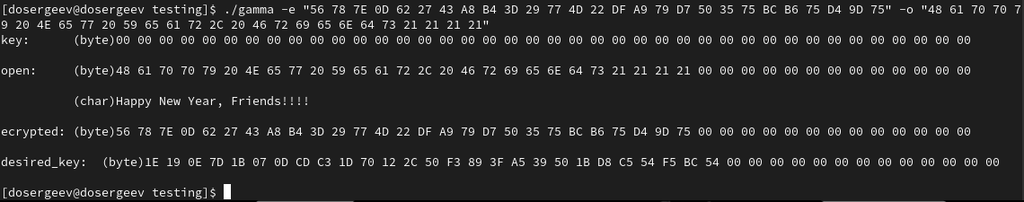

Рисунок 3: Ключ для `Happy New Year, Friends!!!!` и шифротекста

## Выполнение лабораторной работы

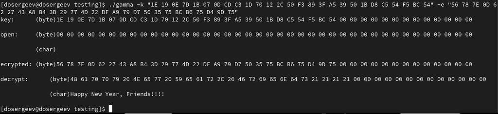

Рисунок 4: Расшифровка фразы из нового ключа и старого шифротекста

Фраза расшифровалась правильно.

## Выполнение лабораторной работы

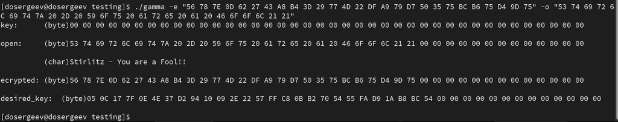

Рисунок 5: Создание ключа для фразы `Stirlitz - You are a Fool!!`

## Выполнение лабораторной работы

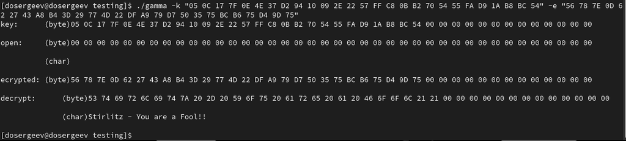

Рисунок 6: Расшифровка фразы `Stirlitz - You are a Fool!!`

Теперь Центр получит сообщение `Stirlitz - You are a Hero!!`, а Мюллер - `Stirlitz - You are a Fool!!`.

# Ответы на контрольные вопросы

1. Поясните смысл однократного гаммирования.
- Однократное гаммирование - это наложение (снятие) на открытые (зашифрованные) данные последовательности элементов других данных, которое использует однократную вероятностную гамму той же длины, что и подлежащий сокрытию текст.
2. Перечислите недостатки однократного гаммирования.
- Необходимость в полной случайности ключа `TRNG`;
- Если злоумышленник знает часть исходного текста и соответствующую шифрограмму, то текст можно расшифровать;
- Использование одной и той же гаммы на разные тексты снижает уровень защиты.

## Ответы на контрольные вопросы

3. Перечислите преимущества однократного гаммирования.
- Даже при раскрытии части последовательности гаммы нельзя получить информацию о всём скрываемом тексте;
- Криптоалгоритм не даёт никакой информации об открытом тексте;
- Вычислительная эффективность.
4. Почему длина открытого текста должна совпадать с длиной ключа?
- В противном случае, нарушается абсолютная стойкость шифротекста. Шифр становится уязвим для частотного анализа и других атак.

## Ответы на контрольные вопросы

5. Какая операция используется в режиме однократного гаммирования, назовите её особенности?
- Применяется операция XOR (исключающее ИЛИ, сложение по модулю 2), её особенность в том, что двойное прибавление одной и той же величины восстанавливает исходное значение, также шифрование и расшифрование выполняется одной и той же программой.

## Ответы на контрольные вопросы

6. Как по открытому тексту и ключу получить шифротекст?
- Применить операцию XOR между последовательностями символов текста и ключа.
7. Как по открытому тексту и шифротексту получить ключ?
- Применить операцию XOR между последовательностями символов текста и шифротекста.
8. В чем заключаются необходимые и достаточные условия абсолютной стойкости шифра?
- Полная случайность ключа;
- Равенство длин ключа и открытого текста;
- Однократное использование ключа.

# Выводы

В результате выполнения лабораторной работы я самостоятельно написал программу, выполняющую однократное гаммирование на заданных примерах. Она способна шифровать сообщение по ключу и открытому тексту, дешифровать по ключу и шифротексту, создавать новый ключ на основе шифротекста и открытого текста. Я на практике освоил одну из простых, но надежных схем шифрования данных.